# Appendix E - Figures of Chinook Model-Generated Stock Composition of Landed Catch for AABM and ISBM Fisheries, 1979-YYYY

## Appendix E4-Chinook Model Estimates of landed catch stock composition for West Coast Vancouver Island troll, 1979-2016

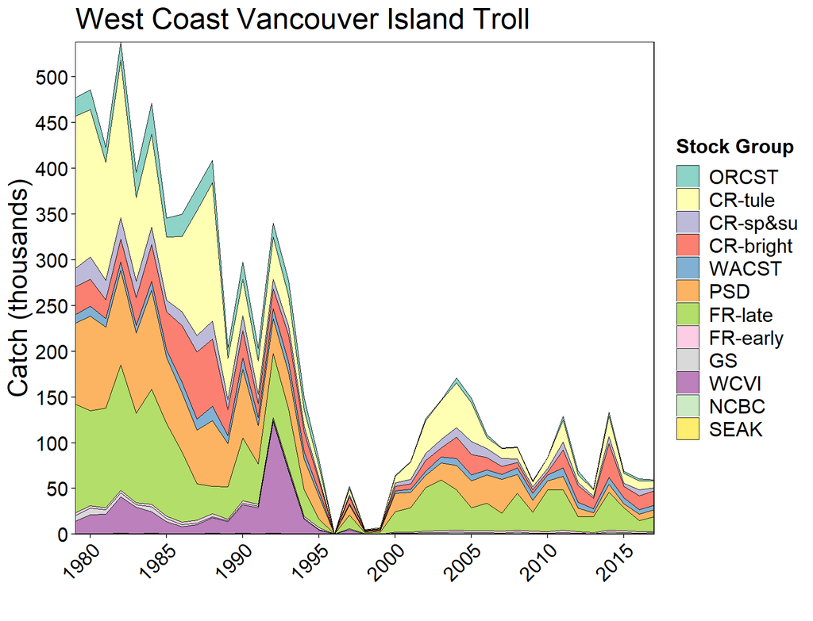

## Appendix E5-Chinook Model Estimates of landed catch stock composition for Washington and Oregon troll, 1979-2016

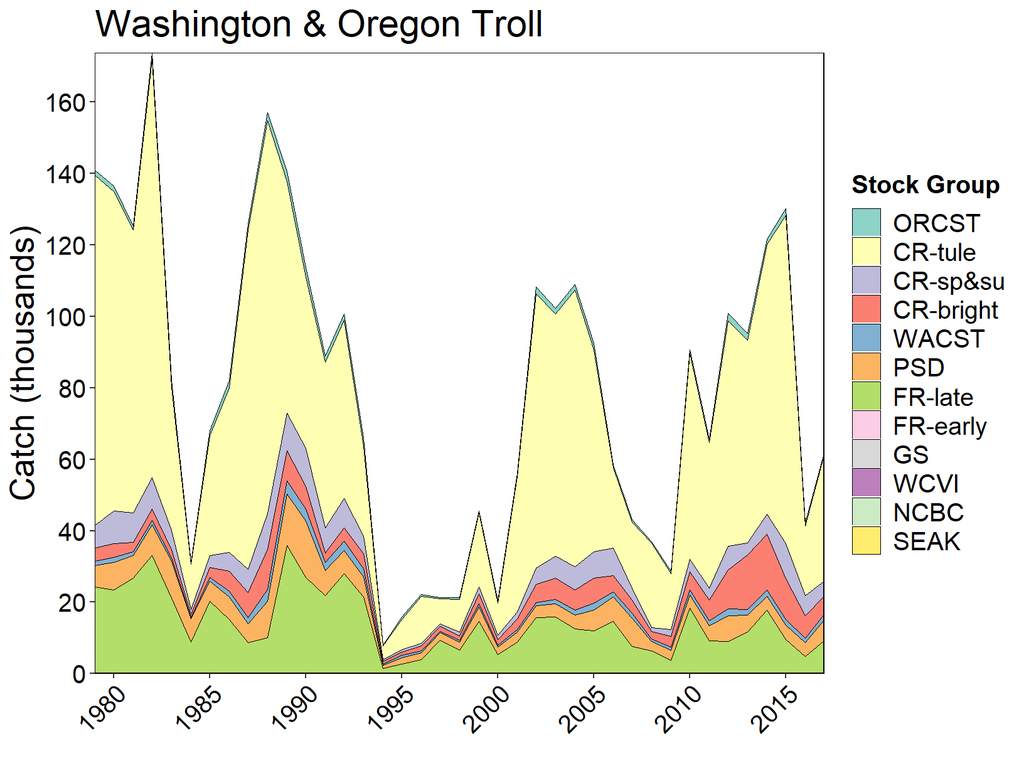

## Appendix E6-Chinook Model Estimates of landed catch stock composition for Strait of Georgia troll, 1979-2016.

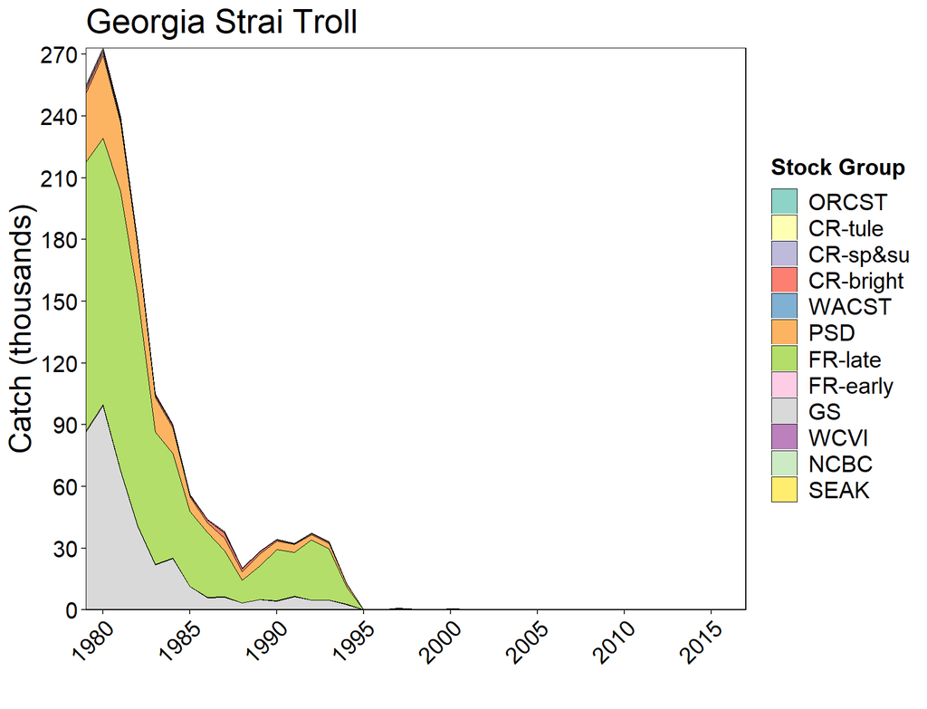

## Appendix E7-Chinook Model Estimates of landed catch stock composition for Alaska net with (upper) and without (lower) hatchery add-on and terminal exclusion, 1979-2016.

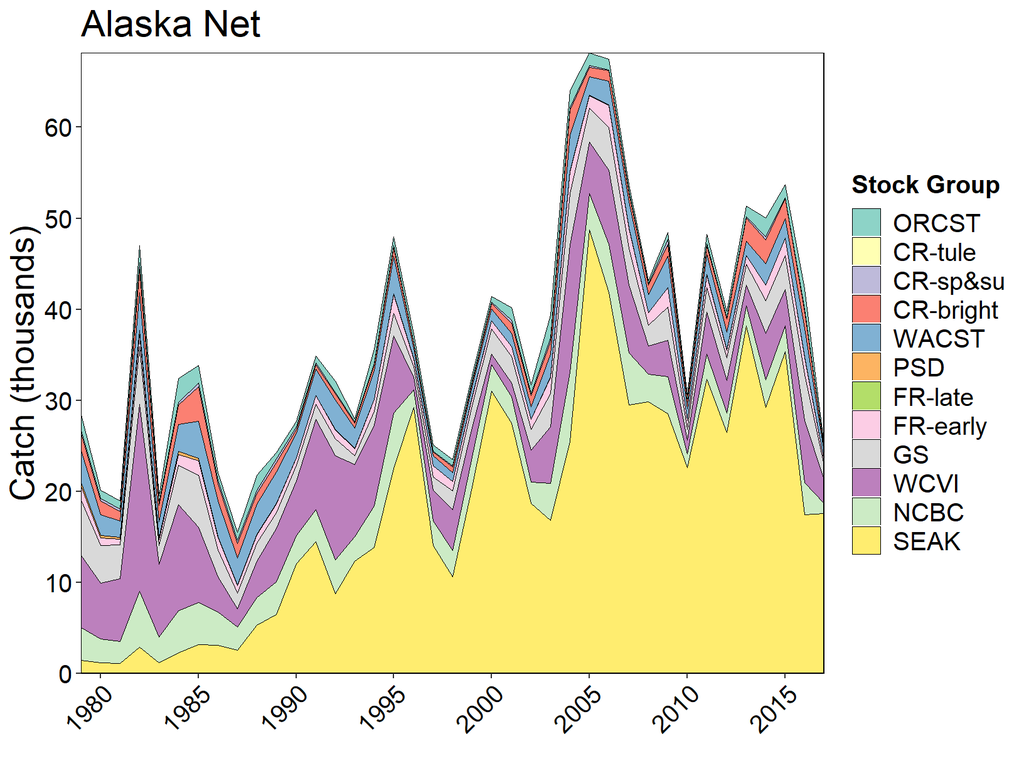

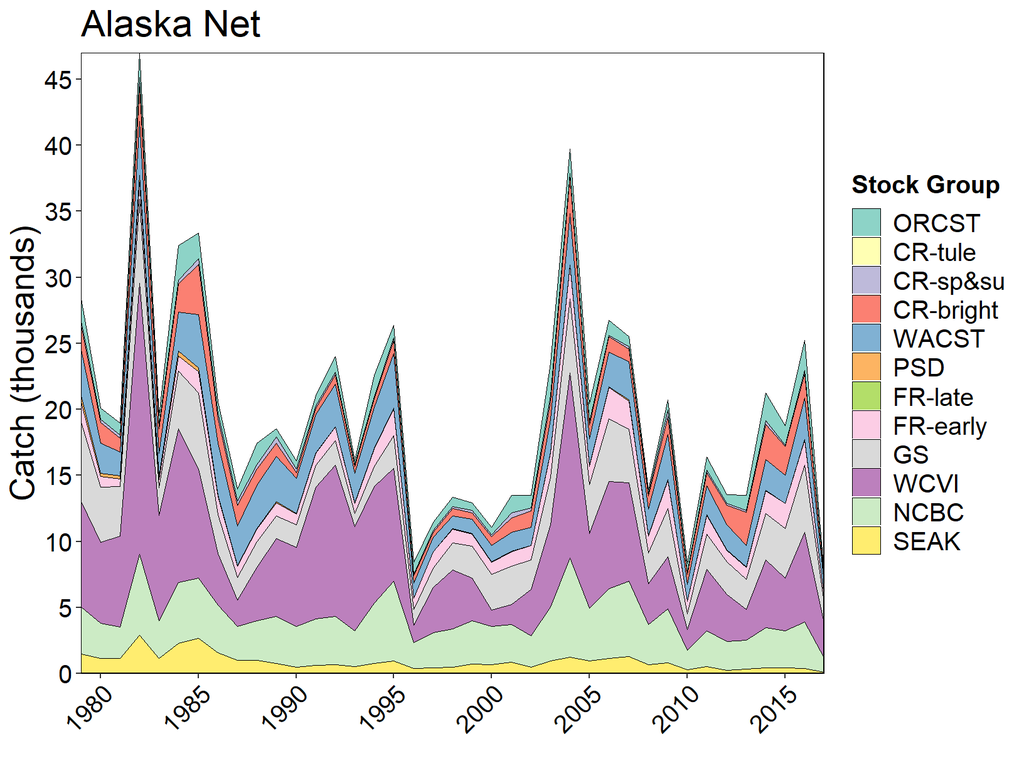

## Appendix E8-Chinook Model Estimates of landed catch stock composition for North British Columbia net, 1979-2016.

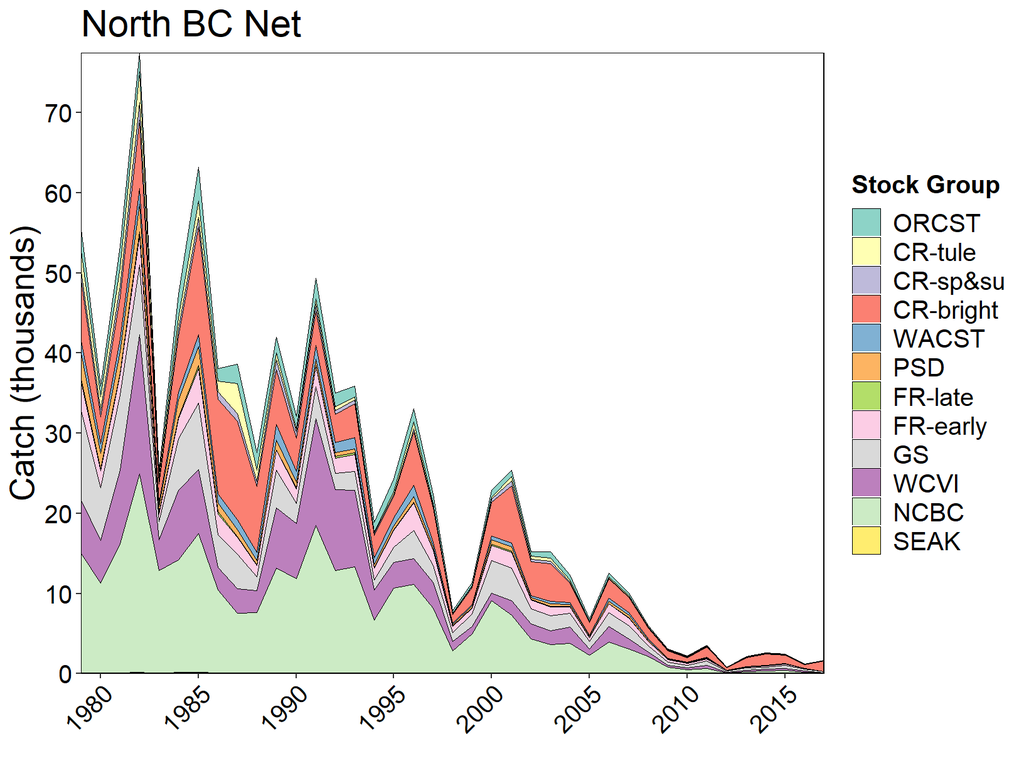

## Appendix E9-Chinook Model Estimates of landed catch stock composition for Central British Columbia net, 1979-2016

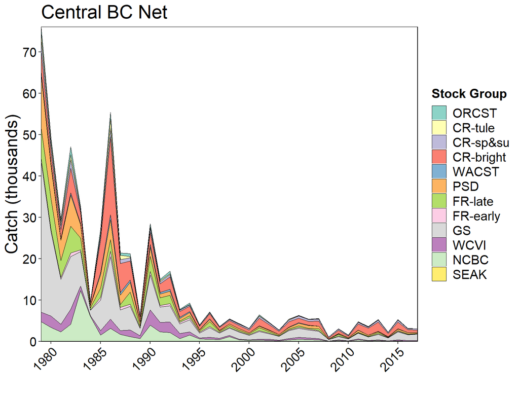

## Appendix E10-Chinook Model Estimates of landed catch stock composition for West Coast Vancouver Island net, 1979-2016

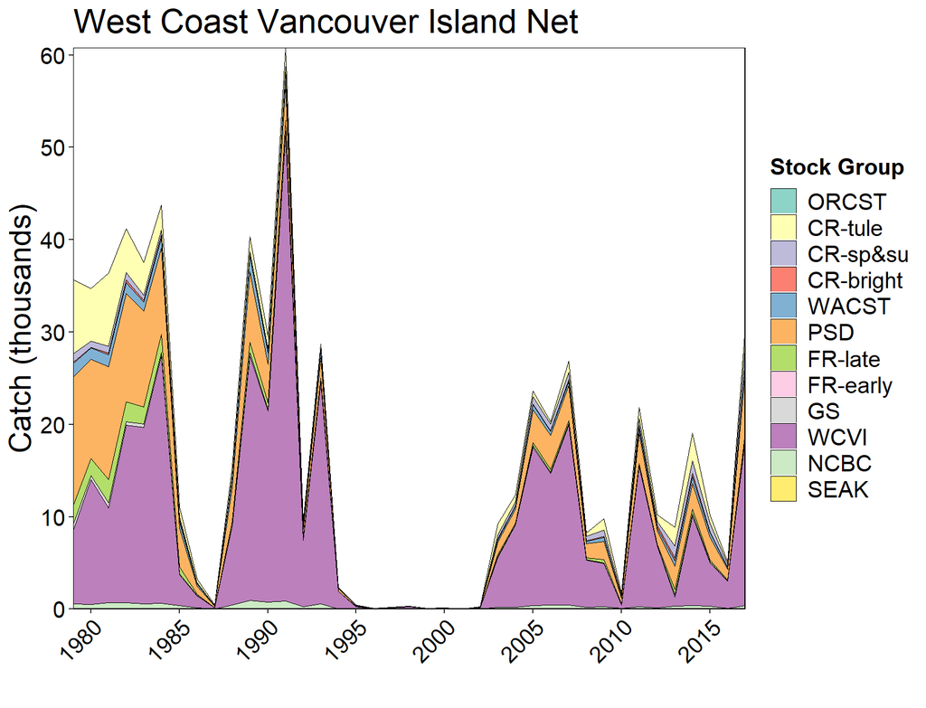

## Appendix E11-Chinook Model Estimates of landed catch stock composition for Strait of Juan de Fuca net, 1979-2016.

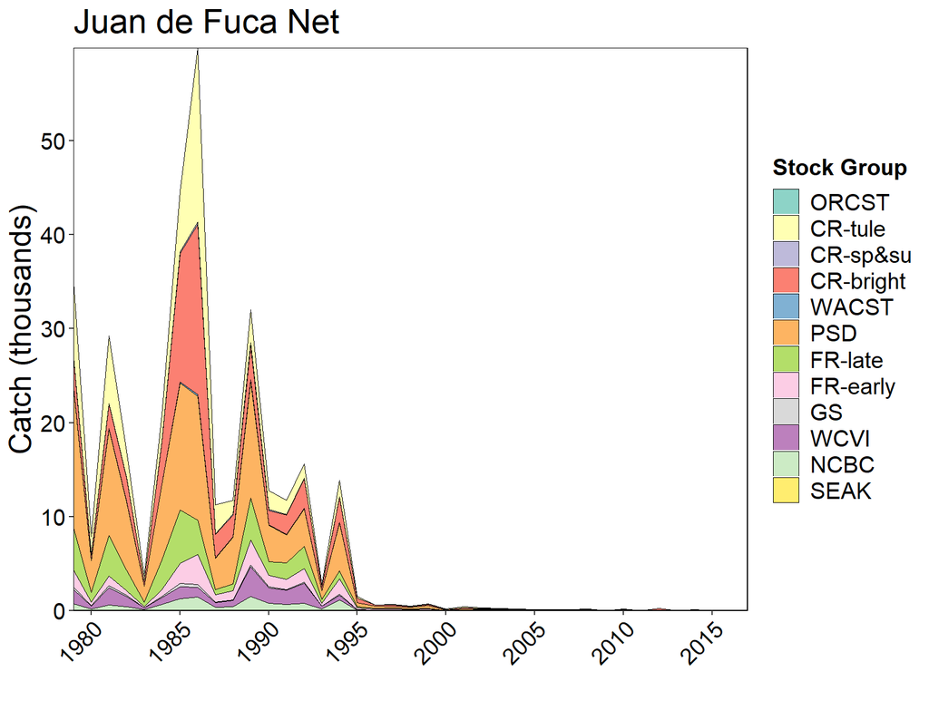

## Appendix E12-Chinook Model Estimates of landed catch stock composition for North Puget Sound net, 1979-2016

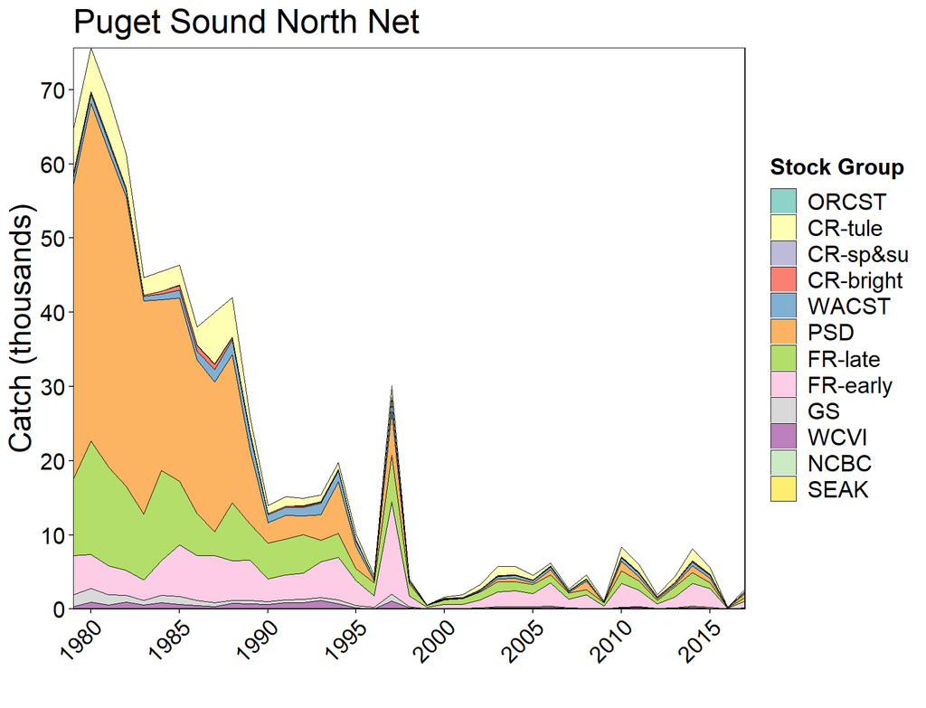

## Appendix E13-Chinook Model Estimates of landed catch stock composition for South Puget Sound net, 1979-2016.

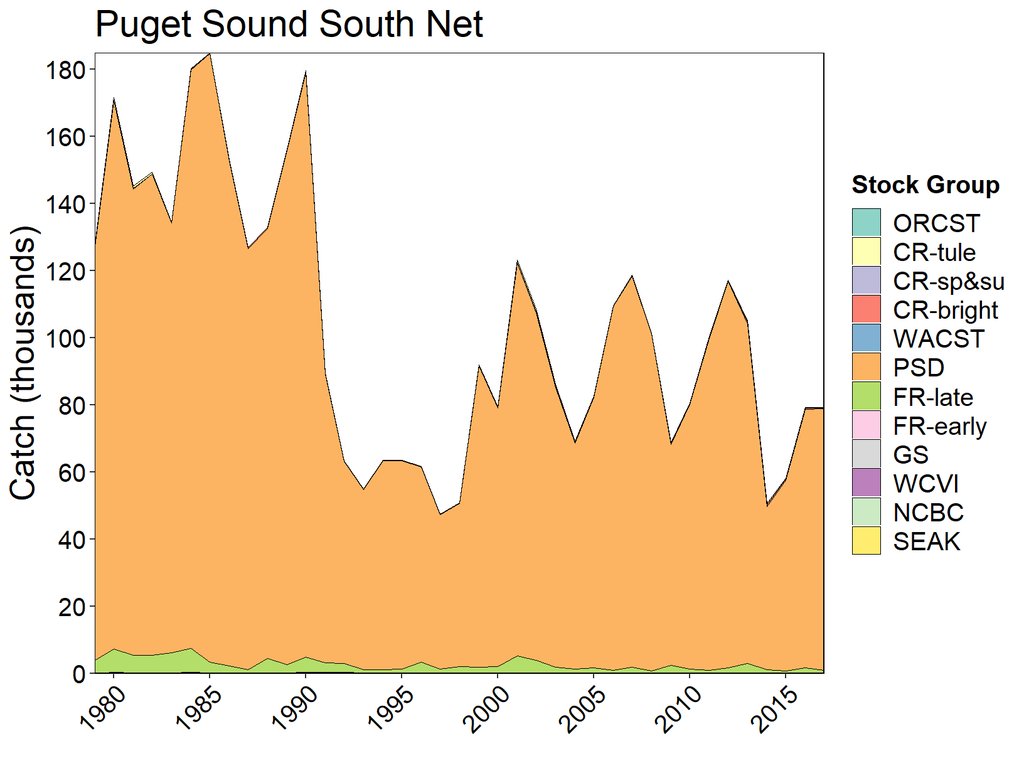

## Appendix E14-Chinook Model Estimates of landed catch stock composition for Washington Coast net, 1979-2016.

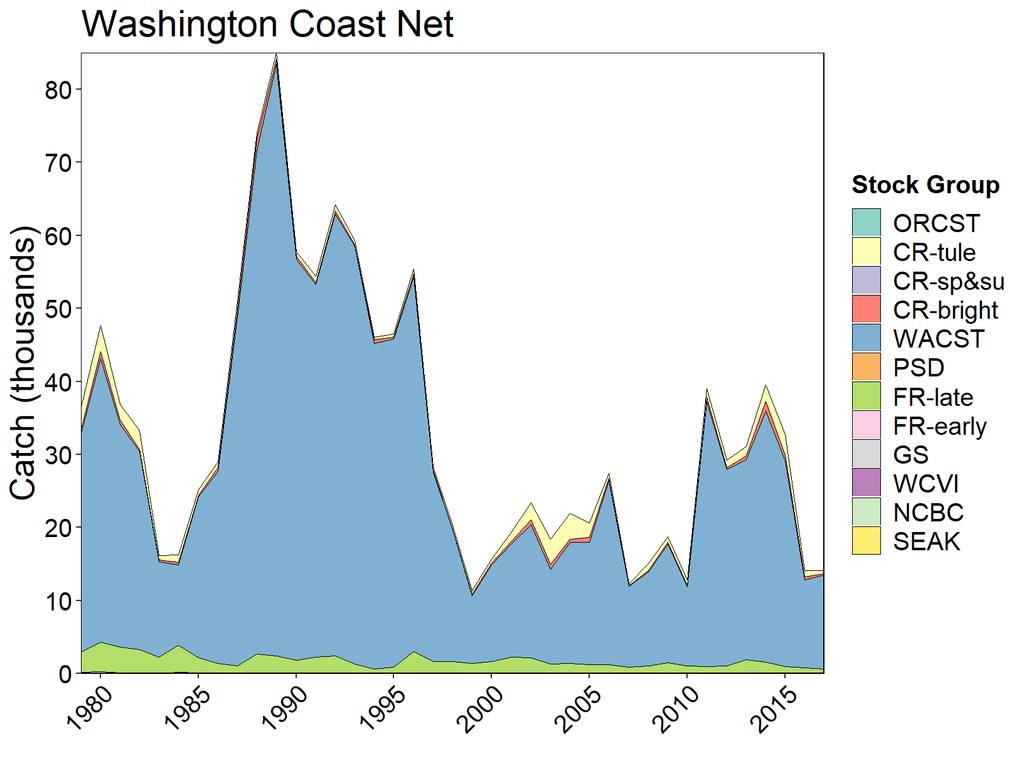

## Appendix E15-Chinook Model Estimates of landed catch stock composition for Columbia River net, 1979-2016.

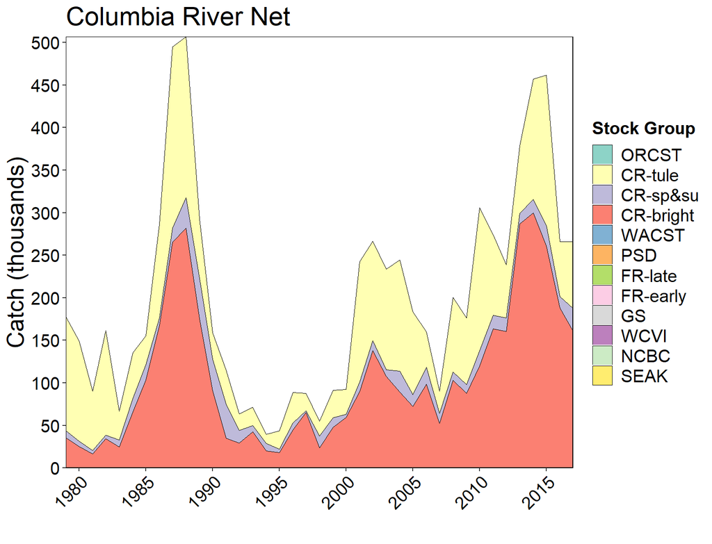

## Appendix E16-Chinook Model Estimates of landed catch stock composition for Johnstone Strait net, 1979-2016.

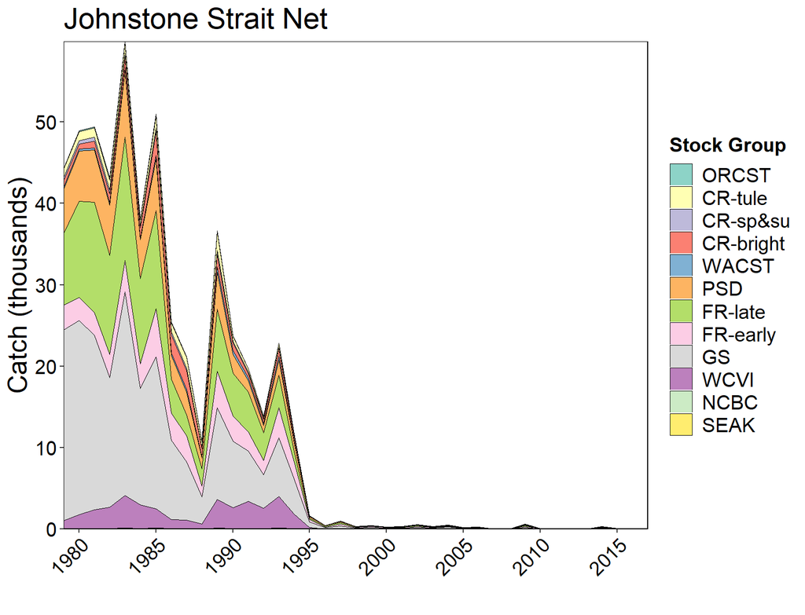

## Appendix E17-Chinook Model Estimates of landed catch stock composition for Fraser River net, 1979-2016.

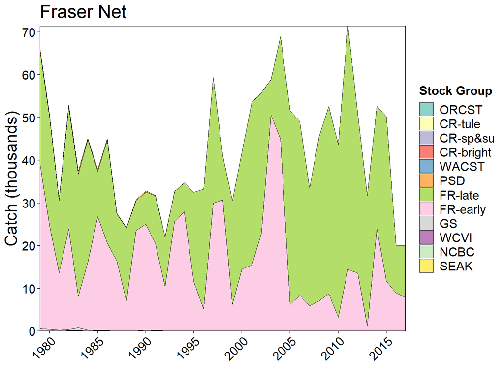

## Appendix E18-Chinook Model Estimates of landed catch stock composition for Alaska sport with (upper) and without (lower) Alaska hatchery add-on and terminal exclusion, 1979-2016.

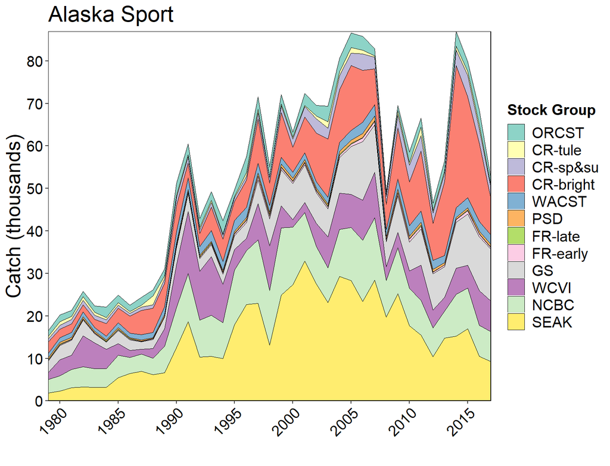

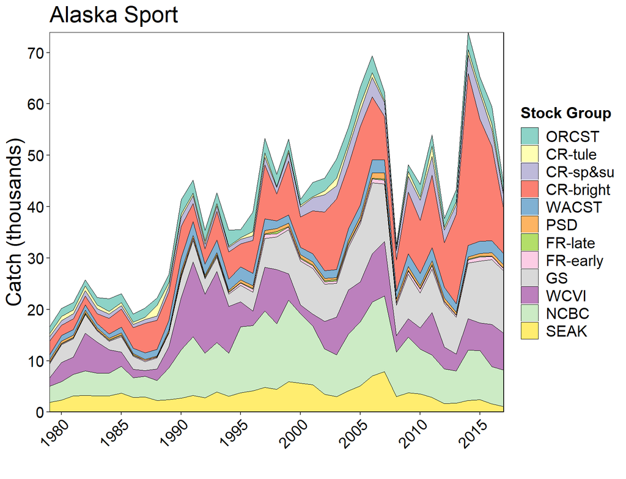

## Appendix E19-Chinook Model Estimates of landed catch stock composition for North and Central British Columbia sport, 1979-2016.

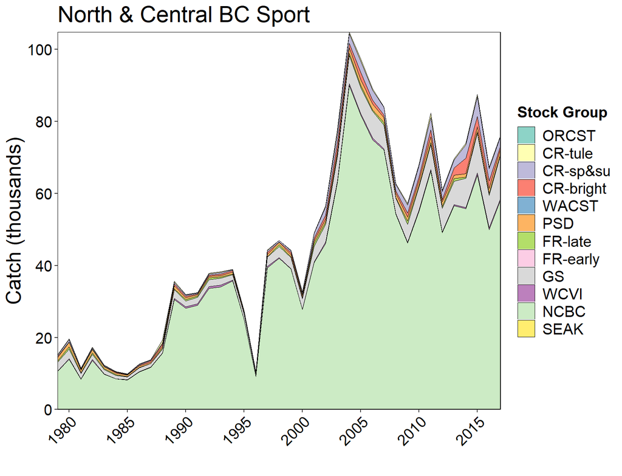

## Appendix E20-Chinook Model Estimates of landed catch stock composition for West Coast Vancouver Island sport, 1979-2016.

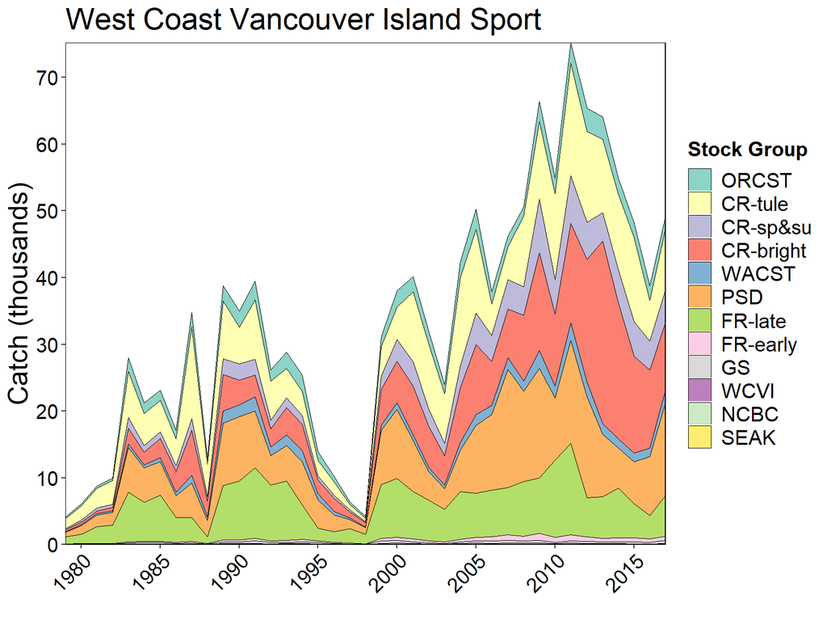

## Appendix E21-Chinook Model Estimates of landed catch stock composition for Washington Ocean sport, 1979-2016.

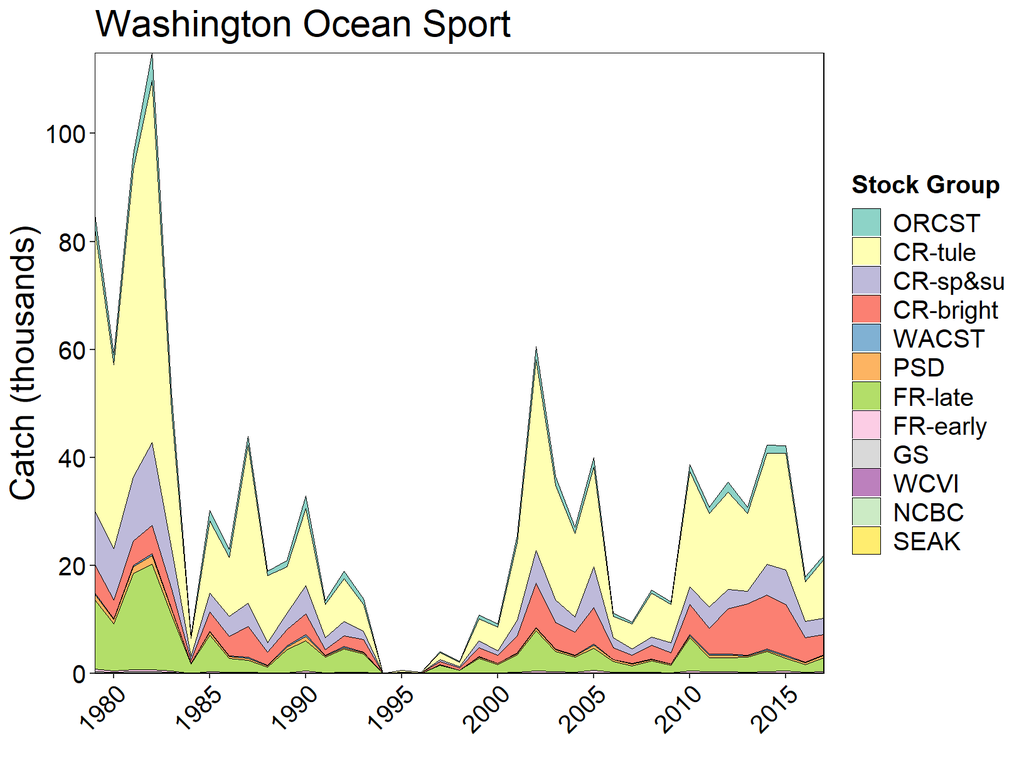

## Appendix E22-Chinook Model Estimates of landed catch stock composition for North Puget Sound sport, 1979-2016.

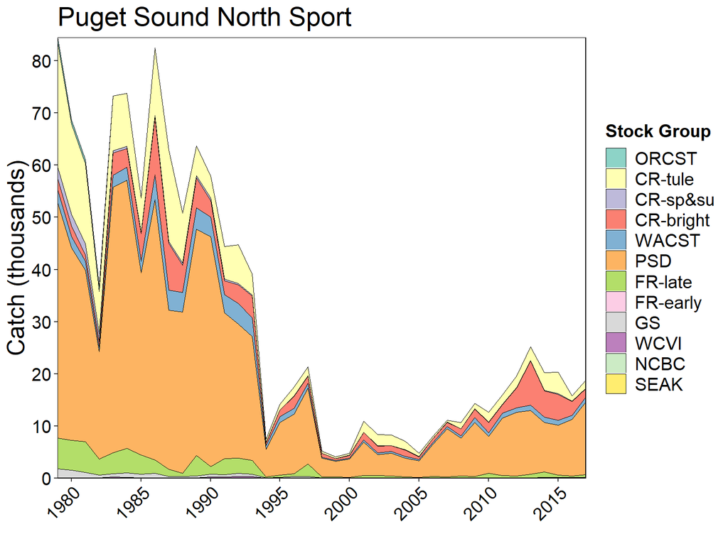

## Appendix E23-Chinook Model Estimates of landed catch stock composition for South Puget Sound sport, 1979-2016.

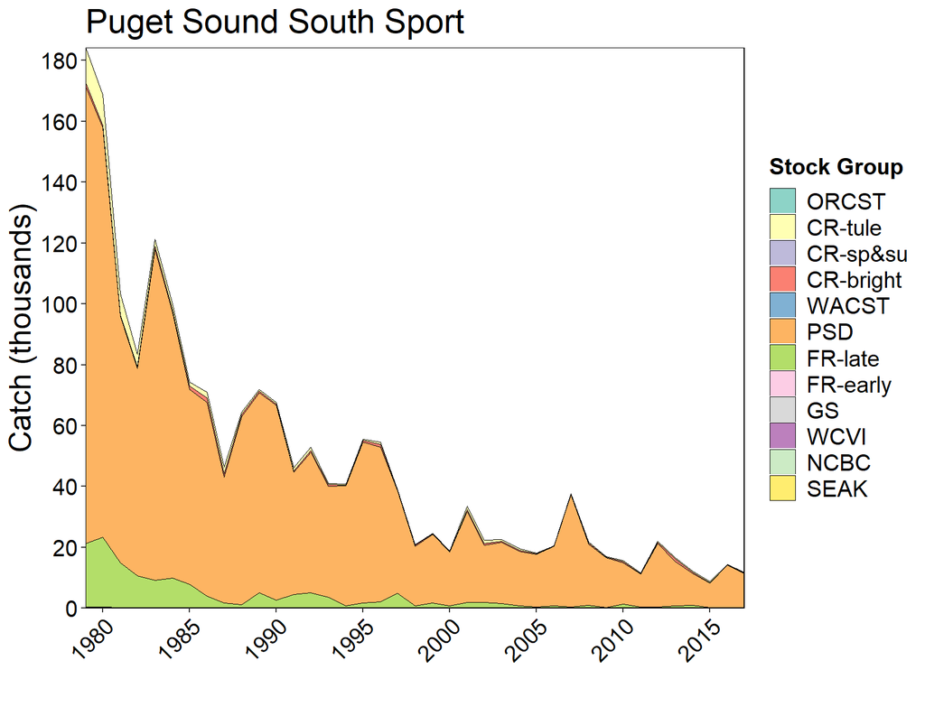

## Appendix E24-Chinook Model Estimates of landed catch stock composition for Strait of Georgia sport, 1979-2016.

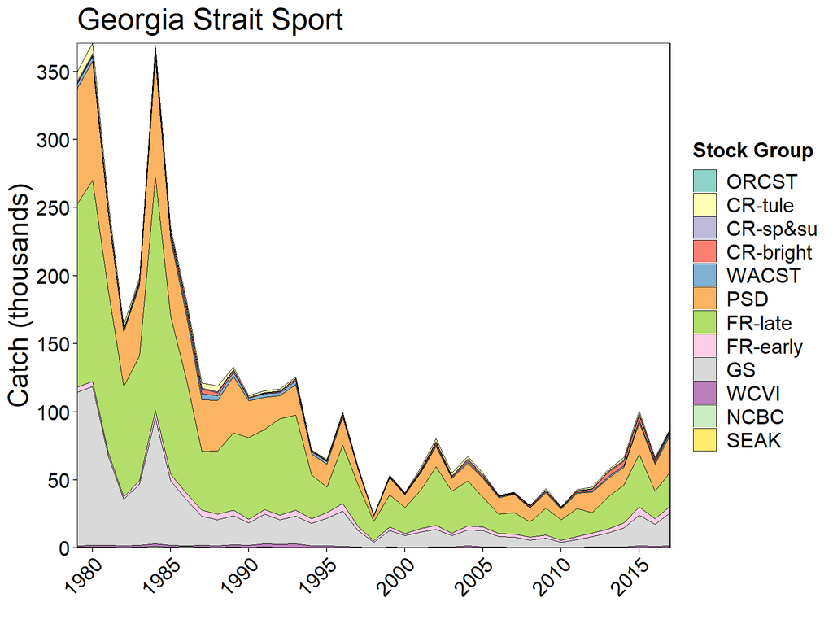

## Appendix E25-Chinook Model Estimates of landed catch stock composition for Terminal sport, 1979-2016.

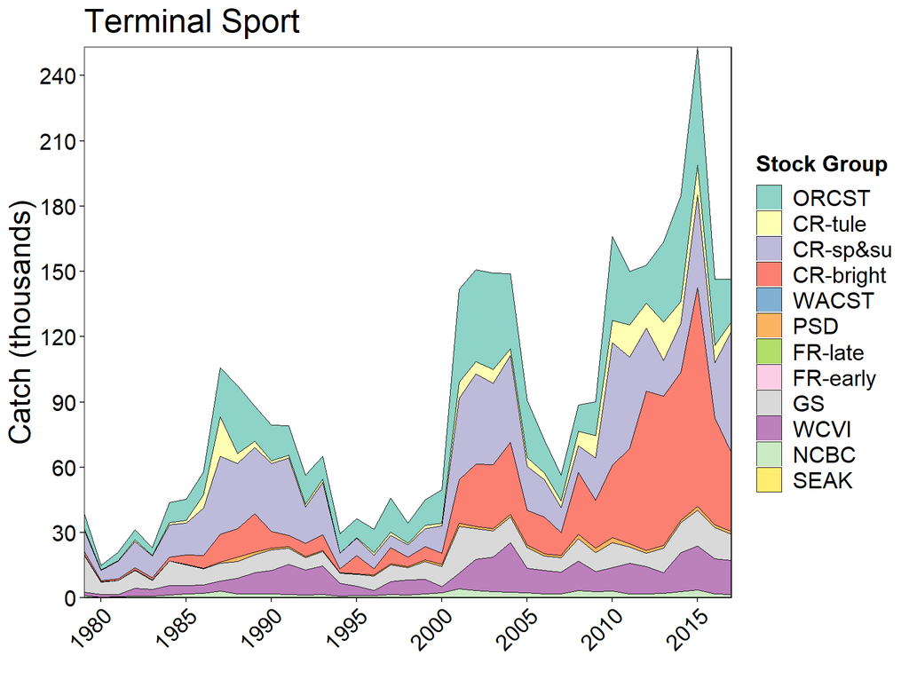